# CRUK Summer School 2017 - Day 4

Geoff Macintyre

## The biology underlying somatic structural variation

Lecture 1

### Exercise 1: Understanding the relationship between SVs and short read sequencing

1. How might the following double-stranded break repair mechanisms manifest in short read sequence data aligned to reference genome at the breakpoint?
   - Homologous recombination
   - Non-homologous end-joining
2. How would the following structural variants manifest in short read sequence data aligned to reference genome?
   - Deletion
   - Tandem duplication
   - Inversion

*(Hint: How many breaks are there? Consider both reads that overlap the break and those that span the break.)*

*Advanced: Can you sketch how reads might overlap translocations?*

## Methods for calling SVs

Lecture 2

### Exercise 2: SV classification

1. Manually (using pen and paper) reconstruct the following set of breakpoints into a single rearrangement event:
   - 2:47676199 + 2:50629634 +
   - 2:49437116 - 2:47678469 -
   - 2:50632712 - 2:49431472 +
2. What might the functional consequence of this rearrangement be?

```
## [1] "http://www.nature.com/ncomms/2015/150401/ncomms7605/extref/ncomms7605-s1.pdf"
```

## Working with SVs

Lecture 3

### Exercise 3 - Visualising SVs

1. Open the test tumour and normal genomes in IGV, navigate to the following locations and record the number of reads supporting each breakpoint.
   - chr1:150447295-150447299
   - chr4:92896530-92896534
   - chr6:24910138-24910139

*(Hint: switch “Show soft-clipped bases” on under Tracks -> Preferences -> Alignments)*

2. Load the deep whole-genome cell-line BRASS output (SV bedpe format) into R.

*(Hint: Use the read.table function with the parameters: header, sep, stringsAsFactors, skip and comment.char. You will also need to reformat the chromosome co-ordinates e.g. change 1 to chr1.)*

```r
SVbedpe<-read.table(gzfile("HCC1143_vs_HCC1143_BL.annot.bedpe.gz"),
                    header = T, sep="\t",stringsAsFactors = F, skip=69, comment.char = "")
colnames(SVbedpe)[1]<-"chr1"
SVbedpe$chr1<-paste0("chr",SVbedpe$chr1)
SVbedpe$chr2<-paste0("chr",SVbedpe$chr2)
```

3. Generate a plot showing the size distributions of the different SV classes.

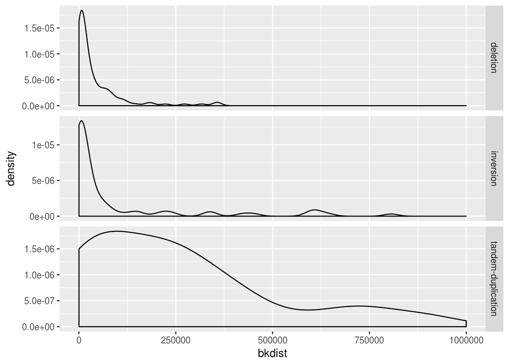

```r
library(ggplot2)
ggplot(SVbedpe[SVbedpe$bkdist>0,],aes(bkdist))+geom_density()+facet_grid(svclass ~ .,scales = "free_y")+xlim(0,1e6)
```

4. Using the circlize package generate a circos plot with SVs as links (use [this](https://cran.r-project.org/web/packages/circlize/vignettes/genomic_plot.pdf) documentation to assist you)

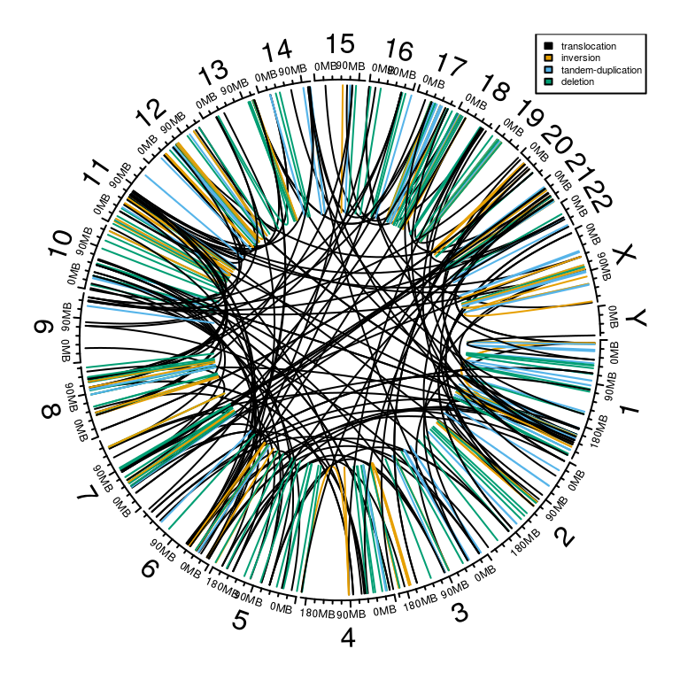

```r
suppressMessages(library(circlize))
par(mar = c(1, 1, 1, 1))
circos.initializeWithIdeogram(plotType = c('axis', 'labels'))
bed1<-SVbedpe[,1:3]
bed2<-SVbedpe[,4:6]
cbbPalette <- c("#000000", "#E69F00", "#56B4E9", "#009E73", "#F0E442", "#0072B2", "#D55E00", "#CC79A7")
colours<-cbbPalette[1:length(unique(SVbedpe$svclass))]
names(colours)<-unique(SVbedpe$svclass)
circos.genomicLink(bed1, bed2,col=colours[SVbedpe$svclass])
legend("topright", legend = names(colours),fill=colours,cex=0.35)
```

### Advanced: Add copy-number calls to your circos plot

```r
ascat.output<-readRDS("ascat.output.rds")
head(ascat.output$segments)
```

```
##    sample chr startpos   endpos nMajor nMinor
## 1 HCC1143   1    61735  6529823      2      2
## 2 HCC1143   1  6530189  8712280      2      1
## 3 HCC1143   1  8716357  9010627      4      1
## 4 HCC1143   1  9011627 20096288      2      1
## 5 HCC1143   1 20099109 23443472      2      2
## 6 HCC1143   1 23444113 43537981      2      1
```

2. Using these segments, add the copy-number calls to your circos plot.

*(Hint: use the genomicTrackPlotRegion function)*

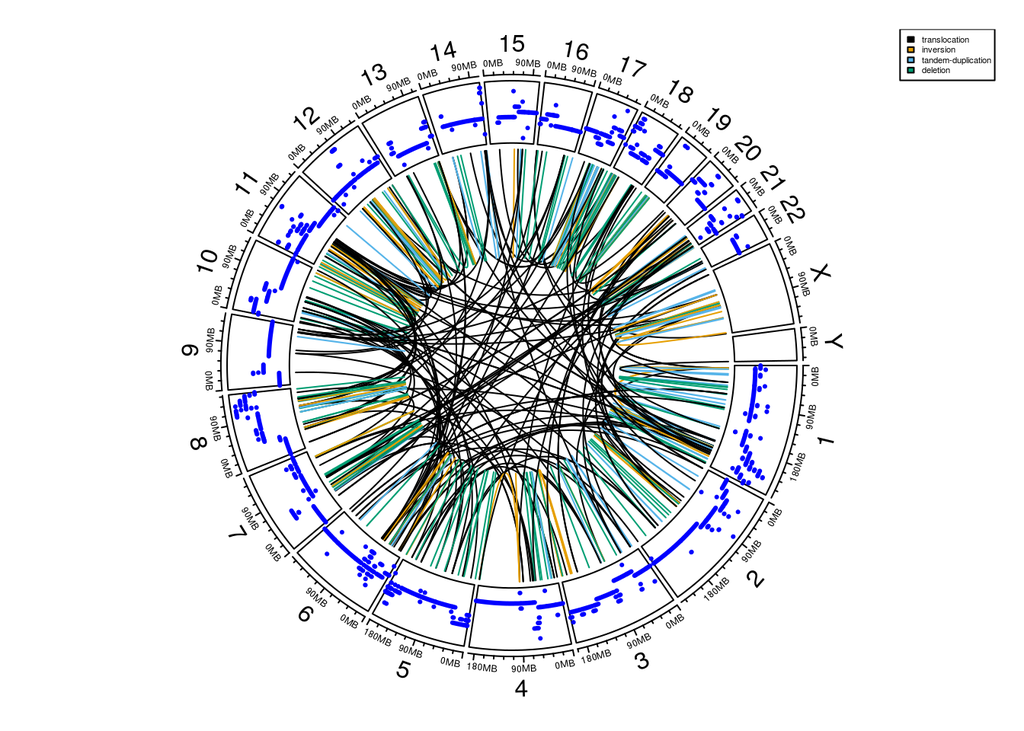

```r
totalcn<-ascat.output$segments[,c("chr","startpos","endpos")]
totalcn<-cbind(totalcn,value=ascat.output$segments$nMajor+ascat.output$segments$nMinor)
totalcn$chr<-paste0("chr",totalcn$chr)
totalcn$value[totalcn$value>10]<-10
circos.initializeWithIdeogram(plotType = c('axis', 'labels'))
circos.genomicTrackPlotRegion(totalcn,ylim=c(0,10),
                              panel.fun=function(region,value,...){
                                i=getI(...)
                 circos.genomicLines(region,value,type="segment",lwd=3,col="blue",...)})
circos.genomicLink(bed1, bed2,col=colours[SVbedpe$svclass])
legend("topright", legend = names(colours),fill=colours,cex=0.35)
```